# Homework 4

STAT 334

Krishnanshu Gupta, Ishaan Sathaye, Sreshta Talluri

2024-05-11

# Question 2

```r
love <- read_xls("./love.xls")
summary(love)
```

```
##       PLS              NGF             AGE        GENDER(0=F,1=M)
##  Min.   : 87.00   Min.   : 24.0   Min.   :18.00   Min.   :0.0000
##  1st Qu.: 95.25   1st Qu.:148.5   1st Qu.:21.00   1st Qu.:0.0000
##  Median :104.00   Median :215.5   Median :25.00   Median :0.0000
##  Mean   :106.38   Mean   :227.9   Mean   :24.40   Mean   :0.3621
##  3rd Qu.:118.75   3rd Qu.:294.0   3rd Qu.:27.75   3rd Qu.:1.0000
##  Max.   :132.00   Max.   :480.0   Max.   :31.00   Max.   :1.0000
##       BDI              STAI           YBOCS
##  Min.   : 0.000   Min.   :20.00   Min.   :0.000
##  1st Qu.: 4.000   1st Qu.:29.00   1st Qu.:1.250
##  Median : 7.000   Median :34.00   Median :4.000
##  Mean   : 6.586   Mean   :33.16   Mean   :3.138
##  3rd Qu.: 9.000   3rd Qu.:37.00   3rd Qu.:5.000
##  Max.   :15.000   Max.   :46.00   Max.   :7.000
```

## Part (a)

```r
model <- lm(NGF ~ PLS + AGE, data = love)
summary(model)
```

```
##
## Call:
## lm(formula = NGF ~ PLS + AGE, data = love)
##
## Residuals:
##      Min       1Q   Median       3Q      Max
## -208.430  -64.914   -2.336   78.839  215.814
##
## Coefficients:
##             Estimate Std. Error t value Pr(>|t|)
## (Intercept) -55.4516   143.4272  -0.387  0.70053
## PLS           2.7699     1.0112   2.739  0.00828 **
## AGE          -0.4638     3.7123  -0.125  0.90104
## ---
## Signif. codes:  0 '***' 0.001 '**' 0.01 '*' 0.05 '.' 0.1 ' ' 1
##
## Residual standard error: 106.6 on 55 degrees of freedom
## Multiple R-squared:  0.1207, Adjusted R-squared:  0.0887
## F-statistic: 3.774 on 2 and 55 DF,  p-value: 0.02911
```

For every one point increase in PLS score, the predicted NGF levels will increase by 2.77, after adjusting for AGE.

## Part (b)

**Null Hypothesis (H0):** $\beta_1$, $\beta_2$ = 0

**Alternate Hypothesis (H1):** At least one of $\beta_1$ or $\beta_2$ $\neq$ 0

$\beta_1$ is the coefficient for PLS score and $\beta_2$ is the coefficient for AGE

**Test Statistic:** F-statistic = 3.774, DF = 58 - 3 = 55

p-value = 0.02911

**Conclusion:** Based on the small p-value of 0.02911, we have sufficient evidence to reject the Null Hypothesis. We have fairly strong evidence to suggest that at least one of the predictors, PLS score or AGE, is a significant predictor of NGF levels. This suggests that including these predictors in the model provides a better fit for explaining the variability in NGF levels compared to a model without these predictors.

## Part (c)

**Null Hypothesis (H0):** $\beta_1$ = 0

**Alternate Hypothesis (H1):** $\beta_1$ > 0

$\beta_1$ is the coefficient for PLS score

**Test Statistic:** t = 2.739, DF = 58 - 3 = 55

p-value = 0.00828 / 2 = 0.00414 (we divide by 2 since it is a one-sided test)

**Conclusion:** Based on the small p-value of 0.00414, we have sufficient evidence to reject the Null Hypothesis. We have very strong evidence of a positive association between PLS score and NGF level, where an increase in PLS score is associated with an increase in NGF level, after adjusting for AGE.

## Part (d)

**Null Hypothesis (H0):** The inclusion of BDI, STAI, and YBOCS does not significantly improve the model’s explanatory power beyond what is provided by PLS and AGE. This implies that coefficients for BDI, STAI, and YBOCS in the extended model are all 0. ($\beta_3$, $\beta_4$, $\beta_5$ = 0)

**Alternate Hypothesis (H1):** The inclusion of BDI, STAI, and YBOCS provides a significant improvement in the model’s explanatory power. (At least one of $\beta_3$, $\beta_4$, $\beta_5$ $\neq$ 0)

```r
extended_model <- lm(NGF ~ PLS + AGE + BDI + STAI + YBOCS, data = love)

# Perform an ANOVA to compare the two models
anova(model, extended_model)
```

```
## Analysis of Variance Table
##
## Model 1: NGF ~ PLS + AGE
## Model 2: NGF ~ PLS + AGE + BDI + STAI + YBOCS
##   Res.Df    RSS Df Sum of Sq      F Pr(>F)
## 1     55 625388
## 2     52 580429  3     44959 1.3426 0.2707
```

**Test Statistic:** F-statistic = 1.3426

**DF:** Model DF = 55; Extended Model DF = 52; Difference in DF = 3

p-value = 0.2707

**Conclusion:** Given the F-statistic of 1.3426 and a p-value of 0.2707, we fail to reject the null hypothesis at a typical alpha level of 0.05. The p-value of 0.2707 indicates that we have insufficient statistical evidence to conclude that the psychiatric rating scales (BDI, STAI, and YBOCS) contribute additional explanatory power to the relationship between NGF levels and the initial predictors (PLS and AGE).

## Part (e)

```r
# Adjusted R-squared for the initial model
summary(model)$adj.r.squared
```

```
## [1] 0.08869951
```

```r
# Adjusted R-squared for the extended model with STAI (only adding STAI for comparison)
model_with_stai <- lm(NGF ~ PLS + AGE + STAI, data = love)
summary(model_with_stai)$adj.r.squared
```

```
## [1] 0.07286507
```

The original model (not including STAI) has a higher adjusted R-squared (0.0887) compared to the new model which includes STAI (0.0729). This indicates that the original model actually explains a slightly larger proportion of the variance in NGF level compared to the new model which includes STAI.

This could be due to the fact that the variance related to NGF levels that STAI could explain is already captured by the other variables, or STAI might not be a relevant predictor for NGF levels in this specific context. Another possible explanation could be that adding STAI could actually decrease the effectiveness of the other variables in the model by introducing noise.

# Problem 3

```r
rails = read_excel("./Rails.xlsx")
head(rails)
```

```
## # A tibble: 6 × 30
##   housenum  acre acregroup  adj1998 adj2007 adj2011 bedgroup bedrooms bikescore
##      <dbl> <dbl> <chr>        <dbl>   <dbl>   <dbl> <chr>       <dbl>     <dbl>
## 1        1  0.28 > 1/4 acre    148.    234.    192. 3 beds          3        35
## 2        2  0.29 > 1/4 acre    135.    261.    207. 3 beds          3        44
## 3        3  0.36 > 1/4 acre    257.    401.    348. 3 beds          3        66
## 4        4  0.26 > 1/4 acre    232.    305.    257. 3 beds          3        61
## 5        5  0.31 > 1/4 acre    272.    299.    237. 4+ beds         4        53
## 6        6  0.31 > 1/4 acre    193.    276.    243. 3 beds          3        36
## # ℹ 21 more variables: diff2014 <dbl>, distance <dbl>, distgroup <chr>,
## #   garage_spaces <dbl>, garagegroup <chr>, latitude <dbl>, longitude <dbl>,
## #   no_full_baths <dbl>, no_half_baths <dbl>, no_rooms <dbl>, pctchange <dbl>,
## #   price1998 <dbl>, price2007 <dbl>, price2011 <dbl>, price2014 <dbl>,
## #   sfgroup <chr>, squarefeet <dbl>, streetname <chr>, streetno <dbl>,
## #   walkscore <dbl>, zip <dbl>
```

## Part (a)

```r
model1 = lm(price2014 ~ distance + squarefeet + no_rooms + no_full_baths + walkscore, data = rails)
summarym1 <- summary(model1)
summarym1
```

```
##
## Call:
## lm(formula = price2014 ~ distance + squarefeet + no_rooms + no_full_baths +
##     walkscore, data = rails)
##
## Residuals:
##     Min      1Q  Median      3Q     Max
## -141.04  -34.02   -1.72   29.61  291.94
##
## Coefficients:
##               Estimate Std. Error t value Pr(>|t|)
## (Intercept)     9.4664    34.4714   0.275   0.7842
## distance        2.9434    10.4164   0.283   0.7781
## squarefeet    116.1915    23.2500   4.997 2.54e-06 ***
## no_rooms        2.5481     7.4199   0.343   0.7320
## no_full_baths  29.2217    12.0664   2.422   0.0173 *
## walkscore       1.0048     0.3832   2.622   0.0101 *
## ---
## Signif. codes:  0 '***' 0.001 '**' 0.01 '*' 0.05 '.' 0.1 ' ' 1
##
## Residual standard error: 62.51 on 98 degrees of freedom
## Multiple R-squared:  0.6977, Adjusted R-squared:  0.6823
## F-statistic: 45.23 on 5 and 98 DF,  p-value: < 2.2e-16
```

Sample Regression Equation: $\hat{Y} = 9.4664 + 2.9434X_1 + 116.1915X_2 + 2.5481X_3 + 29.2217X_4 + 1.0048X_5$, where $\hat{Y}$ is the predicted price of the house in 2014 in thousands of dollars and $X_1$, $X_2$, $X_3$, $X_4$, and $X_5$ are the distance, square feet, number of rooms, number of full baths, and walk score of the house respectively.

Population Regression Equation: $Y = \beta_0 + \beta_1X_1 + \beta_2X_2 + \beta_3X_3 + \beta_4X_4 + \beta_5X_5 + \epsilon$, where $Y$ is the price of the house in 2014 in thousands of dollars, $X_1$, $X_2$, $X_3$, $X_4$, and $X_5$ are the distance, square feet, number of rooms, number of full baths, and walk score of the house respectively, $\beta_0, \beta_1, \beta_2, \beta_3, \beta_4, \beta_5$ are the population parameters, and $\epsilon$ is the error term.

## Part (b)

```r
summarym1$sigma
```

```
## [1] 62.50717
```

s = 62.507 means that the average difference between the observed values and the predicted values is 62.507. Also we expect 95% of the differences to be within 125.014 (2s) of the predicted value.

```r
summarym1$r.squared
```

```
## [1] 0.6976817
```

0.698 means that 69.8% of the variability in the price of the house in 2014 can be explained by the distance, square feet, number of rooms, number of full baths, and walk score of the house.

## Part (d)

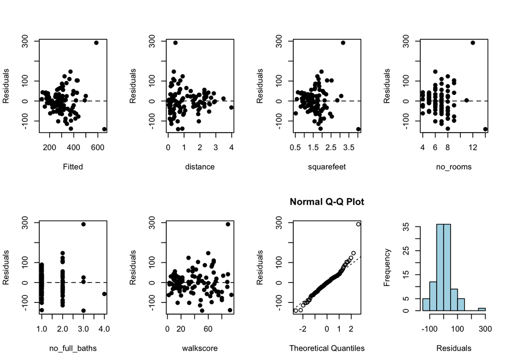

```r
par(mfrow=c(2,4))
plot(resid(model1)~fitted(model1),ylab="Residuals",xlab="Fitted",pch=19)
abline(h=0,lty=2)

plot(resid(model1)~distance, data=rails,ylab="Residuals",pch=19)
abline(h=0,lty=2)

plot(resid(model1)~squarefeet,data=rails,ylab="Residuals",pch=19)
abline(h=0,lty=2)

plot(resid(model1)~no_rooms,data=rails,ylab="Residuals",pch=19)
abline(h=0,lty=2)

plot(resid(model1)~no_full_baths,data=rails,ylab="Residuals",pch=19)
abline(h=0,lty=2)

plot(resid(model1)~walkscore,data=rails,ylab="Residuals",pch=19)
abline(h=0,lty=2)

#normal Q-Q plot and histogram of residuals
qqnorm(resid(model1),ylab="Residuals"); qqline(resid(model1),lty=3)
hist(resid(model1),main="", xlab="Residuals",col='lightblue')
```

```r
library('lmtest')
shapiro.test(resid(model1))
```

```
##
##  Shapiro-Wilk normality test
##
## data:  resid(model1)
## W = 0.94058, p-value = 0.0001539
```

```r
bptest(model1)
```

```
##
##  studentized Breusch-Pagan test
##
## data:  model1
## BP = 29.126, df = 5, p-value = 2.191e-05
```

## Part (e)

**Model-Utility Test**

$H_0$: $\beta_1 = \beta_2 = \beta_3 = \beta_4 = \beta_5 = 0$.

$H_a$: At least one of $\beta_1$, $\beta_2$, $\beta_3$, $\beta_4$, or $\beta_5$ $\neq$ 0.

$\beta_1$, $\beta_2$, $\beta_3$, $\beta_4$, and $\beta_5$ are the coefficients for distance, square feet, number of rooms, number of full baths, and walk score of the house respectively.

```r
summarym1
```

```
##
## Call:
## lm(formula = price2014 ~ distance + squarefeet + no_rooms + no_full_baths +
##     walkscore, data = rails)
##
## Residuals:
##     Min      1Q  Median      3Q     Max
## -141.04  -34.02   -1.72   29.61  291.94
##
## Coefficients:
##               Estimate Std. Error t value Pr(>|t|)
## (Intercept)     9.4664    34.4714   0.275   0.7842
## distance        2.9434    10.4164   0.283   0.7781
## squarefeet    116.1915    23.2500   4.997 2.54e-06 ***
## no_rooms        2.5481     7.4199   0.343   0.7320
## no_full_baths  29.2217    12.0664   2.422   0.0173 *
## walkscore       1.0048     0.3832   2.622   0.0101 *
## ---
## Signif. codes:  0 '***' 0.001 '**' 0.01 '*' 0.05 '.' 0.1 ' ' 1
##
## Residual standard error: 62.51 on 98 degrees of freedom
## Multiple R-squared:  0.6977, Adjusted R-squared:  0.6823
## F-statistic: 45.23 on 5 and 98 DF,  p-value: < 2.2e-16
```

Test Statistic: F-statistic is 45.23

Degrees of Freedom: 104 - 6 = 98

p-value: 2.2e-16

Conclusion: Based on the small p-value of 2.2e-16, we have sufficient evidence to reject the Null Hypothesis. We have extremely strong evidence to conclude that one of the $\beta_i$’s (i = 1,…,5) is not equal to 0, and thus, can conclude that at least one of the variables (distance, square feet, number of rooms, number of full baths, and walk score) is a significant predictor of the price of the house in 2014.

## Part (f)

**Single-Coefficient Test on X1 (distance)**

$H_0$: $\beta_1 = 0$

$H_a$: $\beta_1 \neq 0$

$\beta_1$ is the coefficient for distance.

```r
summarym1 # or Anova(model1, type='II')
```

```
##
## Call:
## lm(formula = price2014 ~ distance + squarefeet + no_rooms + no_full_baths +
##     walkscore, data = rails)
##
## Residuals:
##     Min      1Q  Median      3Q     Max
## -141.04  -34.02   -1.72   29.61  291.94
##
## Coefficients:
##               Estimate Std. Error t value Pr(>|t|)
## (Intercept)     9.4664    34.4714   0.275   0.7842
## distance        2.9434    10.4164   0.283   0.7781
## squarefeet    116.1915    23.2500   4.997 2.54e-06 ***
## no_rooms        2.5481     7.4199   0.343   0.7320
## no_full_baths  29.2217    12.0664   2.422   0.0173 *
## walkscore       1.0048     0.3832   2.622   0.0101 *
## ---
## Signif. codes:  0 '***' 0.001 '**' 0.01 '*' 0.05 '.' 0.1 ' ' 1
##
## Residual standard error: 62.51 on 98 degrees of freedom
## Multiple R-squared:  0.6977, Adjusted R-squared:  0.6823
## F-statistic: 45.23 on 5 and 98 DF,  p-value: < 2.2e-16
```

Test Statistic: t = 0.283

Degrees of Freedom: 104 - 6 = 98

p-value: 0.7781

Conclusion: Based on the large p-value of 0.7781, we do not have sufficient evidence to reject the null hypothesis. The large p-value implies that we do not have enough evidence to believe that $\beta_1$, which is distance, is any different from zero after adjusting for the other variables (square feet, number of rooms, number of full baths, and walk score of the house). Thus, Distance is not a significant predictor for the model.

## Part (g)

**Single-Coefficient Test on X2 (squarefeet)**

$H_0$: $\beta_2 = 0$

$H_a$: $\beta_2 \neq 0$

$\beta_2$ is the coefficient for square feet.

```r
summarym1 # or Anova(model1, type='II')
```

```
##
## Call:
## lm(formula = price2014 ~ distance + squarefeet + no_rooms + no_full_baths +
##     walkscore, data = rails)
##
## Residuals:
##     Min      1Q  Median      3Q     Max
## -141.04  -34.02   -1.72   29.61  291.94
##
## Coefficients:
##               Estimate Std. Error t value Pr(>|t|)
## (Intercept)     9.4664    34.4714   0.275   0.7842
## distance        2.9434    10.4164   0.283   0.7781
## squarefeet    116.1915    23.2500   4.997 2.54e-06 ***
## no_rooms        2.5481     7.4199   0.343   0.7320
## no_full_baths  29.2217    12.0664   2.422   0.0173 *
## walkscore       1.0048     0.3832   2.622   0.0101 *
## ---
## Signif. codes:  0 '***' 0.001 '**' 0.01 '*' 0.05 '.' 0.1 ' ' 1
##
## Residual standard error: 62.51 on 98 degrees of freedom
## Multiple R-squared:  0.6977, Adjusted R-squared:  0.6823
## F-statistic: 45.23 on 5 and 98 DF,  p-value: < 2.2e-16
```

Test Statistic: t = 4.997

Degrees of Freedom: 104 - 6 = 98

p-value: 2.54e-06

Conclusion: Based on the small p-value of 2.54e-06, we have sufficient evidence to reject the null hypothesis. The small p-value implies we have strong evidence to believe that $\beta_2$, which is square feet, is different from zero after adjusting for the other variables (distance, number of rooms, number of full baths, and walk score of the house). Thus, Square feet is a significant predictor of the model.

## Part (h)

**Partial F-Test on X1 and X3, (distance and no_rooms)**

$H_0$: $\beta_1 = \beta_3 = 0$

$H_a$: At least one of $\beta_1$ and $\beta_3 \neq 0$

$\beta_1$ and $\beta_3$ are the coefficients for distance and no_rooms.

```r
library(car)

model2 <- lm(price2014 ~ squarefeet + no_full_baths + walkscore, data = rails)
anova(model2, model1)
```

```
## Analysis of Variance Table
##
## Model 1: price2014 ~ squarefeet + no_full_baths + walkscore
## Model 2: price2014 ~ distance + squarefeet + no_rooms + no_full_baths +
##     walkscore
##   Res.Df    RSS Df Sum of Sq      F Pr(>F)
## 1    100 383844
## 2     98 382900  2    943.91 0.1208 0.8863
```

Test Statistic: F-statistic is 0.1208

Degrees of Freedom: 98

p-value: 0.8863

Conclusion: Based on the large p-value, we don’t have enough evidence to reject the null hypothesis. Therefore adding these 2 variables, distance and no_rooms, to a model already containing the other 3 variables (square feet, number of full baths, and walk score) does not significantly improve the model. We do not have enough evidence that the full model containing all variables is significantly better than the model with just 3 variables. Thus, we can make the decision to use model2 which drops X1 and X3.

## Part (i)

**Partial F-Test on X3 and X4, (no_rooms and no_full_baths)**

$H_0$: $\beta_3 = \beta_4 = 0$

$H_a$: At least one of $\beta_3$ and $\beta_4 \neq 0$

$\beta_3$ and $\beta_4$ are the coefficients for no_rooms and no_full_baths.

```r
library(car)

model3 <- lm(price2014 ~ distance + squarefeet + walkscore, data = rails)
anova(model3, model1)
```

```
## Analysis of Variance Table
##
## Model 1: price2014 ~ distance + squarefeet + walkscore
## Model 2: price2014 ~ distance + squarefeet + no_rooms + no_full_baths +
##     walkscore
##   Res.Df    RSS Df Sum of Sq      F  Pr(>F)
## 1    100 406536
## 2     98 382900  2     23636 3.0247 0.05313 .
## ---
## Signif. codes:  0 '***' 0.001 '**' 0.01 '*' 0.05 '.' 0.1 ' ' 1
```

Test Statistic: F-statistic is 3.0247

Degrees of Freedom: 98

p-value: 0.05313

Conclusion: Based on the p-value of 0.05313, which is greater than our alpha of 0.01, we don’t have sufficient evidence to reject the null hypothesis. Therefore adding these 2 variables, no_rooms and no_full_baths, to a model already containing the other 3 variables (distance, square feet, and walk score) does not significantly improve the model. We do not have enough evidence that the full model containing all variables is significantly better than the model with just 3 variables. Thus, we can make the decision to use model3 which drops X3 and X4.

## Part (j)

Model 2 is better than model 1 due to parsimony, which means that the model with fewer parameters is favored over a complex model. We decided this from the p-value from the partial f test, where we failed to reject the null hypothesis that adding variables to the smaller model to form the larger model does not significantly improve the prediction of house price.

## Part (l)

```r
confint(model1, level = 1 - (1 - 0.95)/5)
```

```
##                       0.5 %     99.5 %
## (Intercept)   -81.087663742 100.020453
## distance      -24.419696576  30.306462
## squarefeet     55.115458582 177.267508
## no_rooms      -16.943464861  22.039709
## no_full_baths  -2.475805131  60.919191
## walkscore      -0.001744542   2.011287
```

We are at least 95% confident that the five intervals simultaneously capture their corresponding population coefficients.

# Problem 4

## Part (a)

```r
#Import the Data
SweetData=read.table('sweetness.txt',header=TRUE)

# By-hand
model <- lm(SweetIndex ~ Pectin, data = SweetData)
x0 = c(1, 300)
predicted_matrix = model$coefficients %*% x0
print(paste("By-hand:", round(predicted_matrix[1], 5)))
```

```
## [1] "By-hand: 5.55888"
```

```r
# predict()
predicted_func = predict(model, data.frame(Pectin = 300))
print(paste("Predict():", round(predicted_func[1], 5)))
```

```
## [1] "Predict(): 5.55888"
```

## Part (b)

```r
s = summary(model)$sigma
rows = length(SweetData$SweetIndex)
df = rows - 2
tstar = qt(0.975, df = df)

# By-hand calculation
X = matrix(c(rep(1, rows), SweetData$Pectin), nrow = rows)
SE = s * sqrt((t(x0) %*% solve(t(X) %*% X) %*% x0))

ci_lower <- predicted_matrix[1] - tstar * SE
ci_upper <- predicted_matrix[1] + tstar * SE

print(paste("By-hand Confidence Interval:", round(ci_lower, 4), "to", round(ci_upper, 4)))
```

```
## [1] "By-hand Confidence Interval: 5.4372 to 5.6806"
```

```r
# predict()
CI <- predict(model, newdata = data.frame(Pectin = 300), interval = "confidence", level = 0.95)
print(paste("Predict() Confidence Interval:", round(CI[2], 4), "to", round(CI[3], 4)))
```

```
## [1] "Predict() Confidence Interval: 5.4372 to 5.6806"
```

We’re 95% confident that the mean sweetness index for all orange juices with 300 ppm of pectin is between 5.4372 and 5.6806.

## Part (c)

```r
# By-hand calculation
SE = s * sqrt(1 + (t(x0) %*% solve(t(X) %*% X) %*% x0))

pi_lower <- predicted_matrix[1] - tstar * SE
pi_upper <- predicted_matrix[1] + tstar * SE

print(paste("By-hand Prediction Interval:", round(pi_lower, 4), "to", round(pi_upper, 4)))
```

```
## [1] "By-hand Prediction Interval: 5.0967 to 6.0211"
```

```r
# predict()
PI <- predict(model, newdata = data.frame(Pectin = 300), interval = "prediction", level = 0.95)
print(paste("Predict() Prediction Interval:", round(PI[2], 4), "to", round(PI[3], 4)))
```

```
## [1] "Predict() Prediction Interval: 5.0967 to 6.0211"
```

We’re 95% confident that an orange juices with 300 ppm of pectin will have a sweetness index between 5.0967 and 6.0211.

## Part (d)

In Part B, we’re calculating the confidence interval, or the average/mean of the response variable, sweetness index, for all pectin values at 300 ppm. The confidence interval only uses the variability of the sample. On the other hand, Part C, uses the prediction interval, which estimates the sweetness index for a particular singular juice at 300 ppm pectin. The prediction interval will use the variability of the sample and the variation of the individual observations at each x value, varying about their mean.

Our results display that the prediction interval is wider than the confidence interval, which supports the statement regarding the additional variability in the prediction interval.